# Neural Mechanisms of Parasite Thermosensation

Astra S. Bryant, PhD

March 03, 2021

# 1 Introduction/Abstract

This purpose of this document is to collect, analyze, and plot data associated with the mansucript titled "Neural Mechanisms of Thermosensation in the Human Parasite *Strongyloides stercoralis*.

# 2 Study Design and Codebook

## 2.1 Thermosensory Calcium Imaging

`TCI_data` is a tidyverse data table containing metadata and results for thermosensory calcium imaging experiments. These data were preprocessed using the TCI Matlab codebase.

### 2.1.1 Experimental Conditions

- Pseudo-fictive PT 20-34$^\circ$C ramp
- Pseudo-fictive PTe 20-40$^\circ$C ramp
- Pseudo-fictive PT15 12-26$^\circ$C ramp
- Pseudo-fictive PT15e 12-32$^\circ$C ramp

### 2.1.2 Data

These data were preprocessed and calculated by TCI Matlab code and are imported into RStudio from the results document generated by Matlab.

- Spearman’s correlation coefficient
- Thermal threshold (T*)
- Caclium response amplitude ($\Delta$R/${R_0}$) at T*

# 3 AFD Response Properties

Thermosensory response properties of *C. elegans* AFD (strain = IK890), and *S. stercoralis* AFD (expression plasmid = pASB52).

## 3.1 Data Inputs

```r
dat_AFD_file <- c('~/Box Sync/Lab_Hallem/Astra/Writing/Bryant et al 20xx/Data/Calcium Imaging/AFDResponse_R_Import.xlsx')

if (is_empty(dat_AFD_file)){
  dat_AFD_file <- file.choose()
}
dat_AFD <- read_excel(dat_AFD_file, sheet = 1) %>%
  group_by(Species,Tc, Stimulus) %>%
  dplyr::mutate(Species = as_factor(Species)) %>%
  dplyr::mutate(Stimulus = as_factor(Stimulus)) %>%
  dplyr::mutate(Tc = as_factor(Tc))

dat_AFD_15 <- dplyr::filter(dat_AFD, Tc == 15)
dat_AFD_23 <- dplyr::filter(dat_AFD, Tc == 23)
```

## 3.2 AFD Plot Templates

```r
source("theme_Publication.R")
plot_AFD <- function(dat, y, ylim, xlabel, ylabel, stat.test, stat.y.position, title = NULL){
  ggplot(data = dat, mapping = aes(x = Species, y = y)) +
    stat_boxplot(geom = "errorbar",
                 width = 0.25,
                 size = .5) +
    geom_boxplot(width = 0.5,
                 outlier.shape = NA,
                 fatten = 1,
                 key_glyph = "rect",
                alpha = 0.3,
                 show.legend = F,
                 aes(fill = Species)) +
    geom_jitter(size = 1,
                stroke = .75,
                width = .2,
                aes(color = Species, shape = Stimulus)) +
     stat_pvalue_manual(stat.test,
                        y.position = stat.y.position,
                         tip.length = 0,
                       bracket.shorten = 0.2,
                        label = 'p.signif') +
    scale_y_continuous(limits = ylim,
                       expand = expansion(add = 0)) +
    scale_color_carto_d(palette = "Vivid") +
    scale_fill_carto_d(palette = "Vivid") +
    scale_shape_manual(values = c(21:23))  +
    xlab(xlabel) +
    ylab(ylabel) +
    ggtitle(title) +
    theme_Publication() +
    theme(aspect.ratio = 2/1)
}

plot_AFD_Speciesfacet <- function(dat, y, ylim, xlabel, ylabel, stat.test, stat.y.position, title = NULL){
  ggplot(data = dat, mapping = aes(x = Tc, y = y)) +
    stat_boxplot(geom = "errorbar",
                 width = 0.25,
                 size = .5) +
    geom_boxplot(width = 0.5,
                 outlier.shape = NA,
                 fatten = 1,
                 key_glyph = "rect",
                 #alpha = 0.3,
                 show.legend = F,
                 aes(fill = Species)) +
    geom_jitter(size = 2,
                stroke = .75,
                width = .2,
                aes(color = Species, shape = Stimulus)) +
     stat_pvalue_manual(stat.test,
                        y.position = stat.y.position,
                        label = 'p.signif') +
    facet_grid(. ~ Species)+
    scale_y_continuous(limits = ylim,
                       expand = expansion(add = 0)) +
    scale_color_carto_d(palette = "Vivid") +
    scale_fill_carto_d(palette = "Vivid") +
    scale_shape_manual(values = c(21:23))  +
    xlab(xlabel) +
    ylab(ylabel) +
    ggtitle(title) +
     theme_Publication() +
    theme(aspect.ratio = 2/1)
}

plot_AFD_Tcfacet <- function(dat, y, ylim, xlabel, ylabel, stat.test, stat.y.position, title = NULL){
  ggplot(data = dat, mapping = aes(x = Species, y = y)) +
    stat_boxplot(geom = "errorbar",
                 width = 0.25,
                 size = .5) +
    geom_boxplot(width = 0.5,
                 outlier.shape = NA,
                 fatten = 1,
                 key_glyph = "rect",
                 #alpha = 0.3,
                 show.legend = F,
                 aes(fill = Species)) +
    geom_jitter(size = 2,
                size = .75,
                width = .2,
                aes(color = Species, shape = Stimulus)) +
     stat_pvalue_manual(stat.test,
                        y.position = stat.y.position,
                        label = 'p.signif') +
    facet_grid(. ~ Tc)+
    scale_y_continuous(limits = ylim,
                       expand = expansion(add = 0)) +
    scale_color_carto_d(palette = "Vivid") +
    scale_fill_carto_d(palette = "Vivid") +
    scale_shape_manual(values = c(21:23))  +
    xlab(xlabel) +
    ylab(ylabel) +
    ggtitle(title) +
    theme_Publication() +
    theme(aspect.ratio = 2/1)
}
```

## 3.3 Temperature Threshold

The temperature threshold for each worm. Threshold is defined as the temperature at which point the caclium response deviates from baseline (F0) response by at least 3 * STD of baseline, for the duration of time it takes for the stimulus ramp to advance 0.25C. For the slow temperature ramps (.025C/s) plotted here, this time is therefore 10 seconds.

Baseline (F0) responses are defined as the calcium responses at the followin temperatures:

- For Tc = 23, F0 = 20C
- For Tc = 15, F0 = 12C

Statistics are the results of Wilcoxon signed-rank tests.

### 3.3.1 Tc = 23C

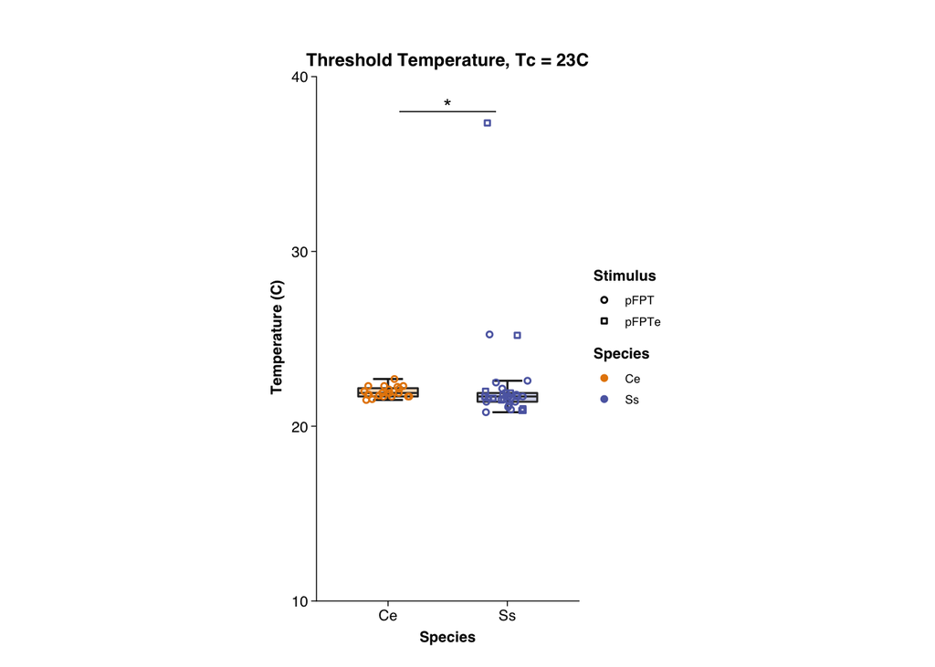

```r
xlabel <- "Species"
ylabel <- " Temperature (C)"
title <- "Threshold Temperature, Tc = 23C"
ylim <- c(10, 40)

stat.thresh.23 <- compare_means(Temperature ~ Species,
                           data = dat_AFD_23,
                           p.adjust.method = "bonferroni")

p.thresh.23 <- plot_AFD(dat_AFD_23,
         dat_AFD_23$Temperature,
         ylim,
         xlabel,
         ylabel,
         stat.thresh.23,
         38,
         title)

print(p.thresh.23)
```

### 3.3.2 Tc = 15C

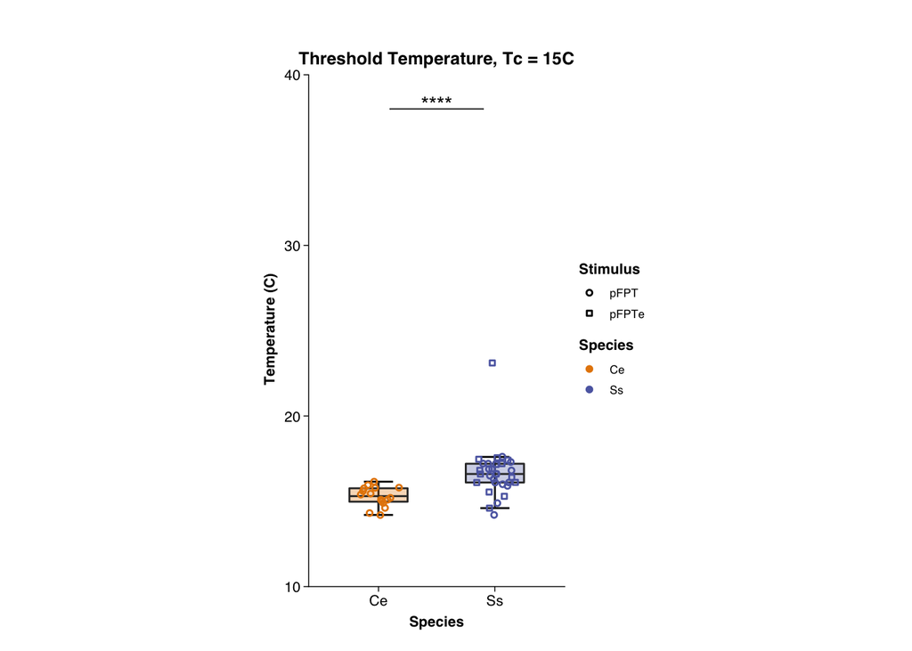

```r
xlabel <- "Species"
ylabel <- " Temperature (C)"
title <- "Threshold Temperature, Tc = 15C"
ylim <- c(10, 40)

stat.thresh.15 <- compare_means(Temperature ~ Species,
                           data = dat_AFD_15,
                           p.adjust.method = "bonferroni")

p.thresh.15 <- plot_AFD(dat_AFD_15,
         dat_AFD_15$Temperature,
         ylim,
         xlabel,
         ylabel,
         stat.thresh.15,
         38,
         title)

print(p.thresh.15)
```

## 3.4 Calcium Response at T*

The amplitude of the calcium response at thermal threshold for each worm. Statistics are Wilcoxon signed-rank tests.

### 3.4.1 Tc = 23C

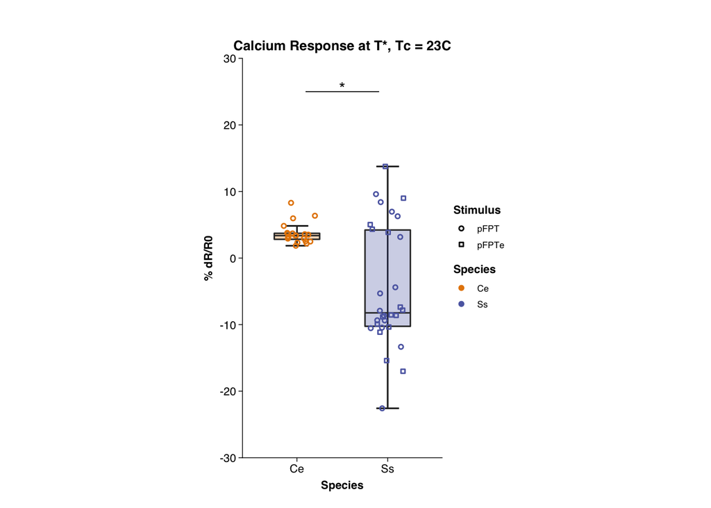

```r
ylabel <- "% dR/R0"
title <- "Calcium Response at T*, Tc = 23C"
ylim <- c(-30, 30)

stat.threshresp.23 <- compare_means(CaResponse ~ Species,
                           data = dat_AFD_23)

p.threshresp.23 <- plot_AFD(dat_AFD_23,
         dat_AFD_23$CaResponse,
         ylim,
         xlabel,
         ylabel,
         stat.threshresp.23,
         25,
         title)

print(p.threshresp.23)
```

### 3.4.2 Tc = 15C

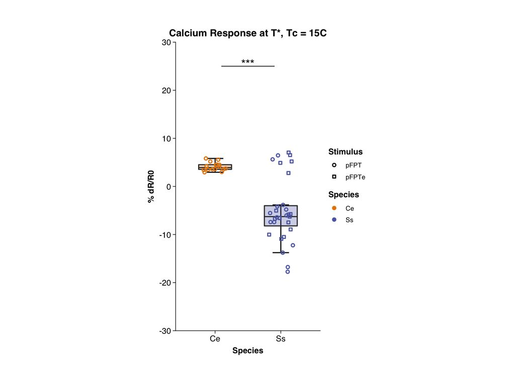

```r
ylabel <- "% dR/R0"
title <- "Calcium Response at T*, Tc = 15C"
ylim <- c(-30, 30)

stat.threshresp.15 <- compare_means(CaResponse ~ Species,
                           data = dat_AFD_15)

p.threshresp.15 <- plot_AFD(dat_AFD_15,
         dat_AFD_15$CaResponse,
         ylim,
         xlabel,
         ylabel,
         stat.threshresp.15,
         25,
         title)

print(p.threshresp.15)
```

### 3.4.3 Bar Graph

Plot showing proportion of worms in two categories:

- “Negative” = calcium response amplitude at threshold is negative (generally heating-mediated hyperpolarization responses)
- “Positive” = calcium response amplitude at threshold is positive (heating-mediate depolarizations)

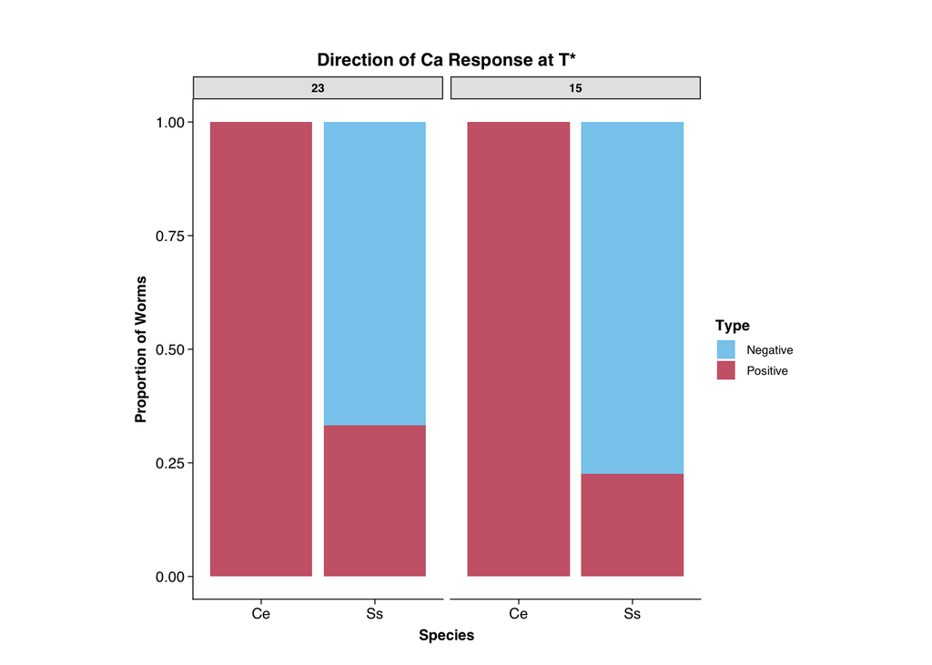

```r
xlabel <- "Species"
ylabel <- "Proportion of Worms"
title <- "Direction of Ca Response at T*"

dat_bar <- dat_AFD %>%
  dplyr::mutate(Type = as_factor(case_when(
    CaResponse > 0 ~ "Positive",
    CaResponse < 0 ~ "Negative"))) %>%
  dplyr::mutate(Type = relevel(Type, "Negative")) %>%
  dplyr::mutate(Tc = relevel(Tc, "23")) %>%
  dplyr::group_by(Tc, Species, Type)


  p.bar <- ggplot(data = dat_bar, mapping = aes(x = Species)) +
    geom_bar(aes(fill = Type), position = "fill") +
    scale_color_carto_d(palette = "Safe") +
    scale_fill_carto_d(palette = "Safe") +
    facet_wrap(~Tc)+
    xlab(xlabel) +
    ylab(ylabel) +
    ggtitle(title) +
    theme_Publication() +
    theme(aspect.ratio = 2/1)

  print(p.bar)
```

## 3.5 Spearman Correlation

Is the calcium response linearly correlated with changes in temperature. Correlation between calcium repsonses and temperature are analyzed across the following temperature ranges:

- For Tc = 23, from 25 - 34C (pF PT) or 25 - 40C (pF PTe)
- For Tc = 15, from 17 - 26C (pF PT15) or 17 - 32C (pF PT15e)

### 3.5.1 Tc = 23C

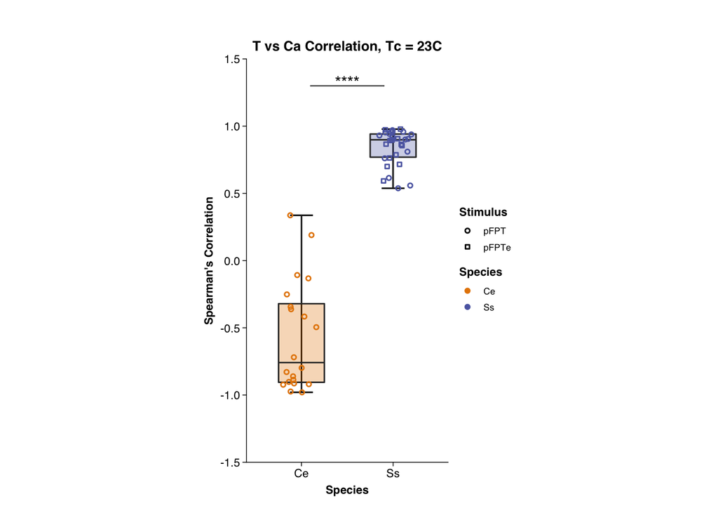

```r
ylabel <- "Spearman's Correlation"
title <- "T vs Ca Correlation, Tc = 23C"
ylim <- c(-1.5, 1.5)
stat.spearman.23 <- compare_means(AboveThSpearmanR ~ Species,
                           data = dat_AFD_23)

p.spearman.23 <- plot_AFD(dat_AFD_23,
         dat_AFD_23$AboveThSpearmanR,
         ylim,
         xlabel,
         ylabel,
         stat.spearman.23,
         1.3,
         title)

print(p.spearman.23)
```

### 3.5.2 Tc = 15C

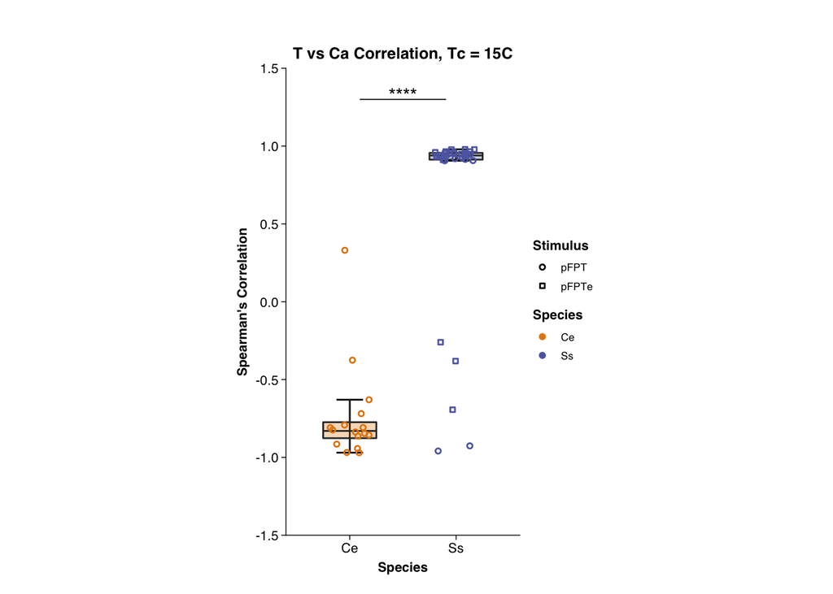

```r
ylabel <- "Spearman's Correlation"
title <- "T vs Ca Correlation, Tc = 15C"
ylim <- c(-1.5, 1.5)
stat.spearman.15 <- compare_means(AboveThSpearmanR ~ Species,
                           data = dat_AFD_15)

p.spearman.15 <- plot_AFD(dat_AFD_15,
         dat_AFD_15$AboveThSpearmanR,
         ylim,
         xlabel,
         ylabel,
         stat.spearman.15,
         1.3,
         title)

print(p.spearman.15)
```

## 3.6 Group and Save AFD Plots

```r
ggarrange(
  p.thresh.23,
  p.thresh.15,
  p.threshresp.23,
  p.threshresp.15,
  p.spearman.23,
  p.spearman.15,
  p.bar,
  ncol = 2,
  nrow = 4
) %>%
ggsave(filename ="AFD_Plots.pdf",
       device = cairo_pdf,
       width = 7,
       height = 9.5,
       path = dirname(dat_AFD_file))
```

# 4 Ss-AFD-rGC Ecoptic Expression Analysis

Analysis and plotting for a series of experiments testing the effect of ectopic expression of *Strongyloides stercoralis* AFD rGCs in *C. elegans* ASE neurons.

## 4.1 Data Inputs

Data are preprocessed using Matlab TCI file `TCI_analyzeEctopic.m`, which calculates the temperature at which point an experimental trace rises above 3*rms of mean control trace for at least 6 seconds. This calculation is run independently for each trace, and the value (in degrees C) is saved.

```r
dat_ectopic_file <- c('~/Box Sync/Lab_Hallem/Astra/Writing/Bryant et al 20xx/Data/Calcium Imaging/Ectopic Expression/EctopicExpression_R_Import.xlsx')
#dat_file <- NULL
if (is_empty(dat_ectopic_file)){
  dat_ectopic_file <- file.choose()
}
meta_ectopic <-read_excel(dat_ectopic_file, sheet = "Metadata")
dat_ectopic <- read_excel(dat_ectopic_file, sheet = 1) %>%
  group_by(rGC,Strain)


dat_ectopic_filtered <- dat_ectopic %>%
  dplyr::filter(rGC != "ASE_ctrl") %>%
  dplyr::filter(!is.na(Thresh_temp)) %>%
  dplyr::bind_rows(dplyr::filter(dat_ectopic, rGC == "ASE_ctrl"))
```

## 4.2 rGC Plot Templates

```r
source("theme_Publication.R")

plot_ectopic_noctrl <- function(dat, y, meta, ylim, xlabel,
                                ylabel, stat.test,
                                stat.y.position,
                                title = NULL){
  ggplot(data = dat, mapping = aes(x = rGC, y = y)) +

    stat_boxplot(geom = "errorbar",
                 width = 0.25,
                 size = 0.5) +
    geom_boxplot(width = 0.5,
                 outlier.shape = NA,
                 fatten = 1,
                 key_glyph = "rect",
                 alpha = 0.3,
                 aes(fill = rGC)) +
    geom_jitter(size = 2,
                stroke = .75,
                width = .2,
                aes(color = Strain, shape = Strain)) +
    stat_pvalue_manual(stat.test,
                        y.position = stat.y.position,
                       step.increase = 0.1,
                       tip.length = 0,
                       hide.ns = TRUE,
                       bracket.shorten = 0.2,
                       label = "p.adj.signif"
                       ) +
    scale_y_continuous(limits = ylim,
                       expand = expansion(add = 0)) +
    xlab(xlabel) +
    ylab(ylabel) +
    ggtitle(title) +
    scale_fill_manual(values = c("darkorchid4", "cyan4", "coral4"))+
    #scale_color_carto_d(palette = "Bold") +
    scale_color_manual(values = c(rep(c("darkorchid4","cyan4", "coral4"),each = 3)))+
    scale_shape_manual(values = rep(c(21:23), 3))  +
    theme_Publication() +
    theme(aspect.ratio = 4/3,
          axis.text.x = element_text(angle= 45,

                                     hjust = 1))
}
```

## 4.3 Temperature Threshold

Stats are Kruskal-Wallis Test with Dunn’s Post tests for difference in response amplitude.

```r
# ---- Temperature Threshold Plot ----

xlabel <- "Ss-AFD-rGCs"
ylabel <- " Temperature (C)"
title <- "Threshold Temperature"
ylim <- c(19, 45)

dat.subset <-dplyr::filter(dat_ectopic_filtered, rGC != "ASE_ctrl")%>%
  dplyr::mutate(Strain = as_factor(Strain)) %>%
  dplyr::mutate(rGC = as_factor(rGC))

# Kruskal-Wallis testing of response amplitude differenec
one.way <- kruskal.test(Thresh_temp ~ rGC,
                        data = dat.subset)

# Posthoc Dunn tests with Bonferroni adjustment
post.hoc <- dunn.test::dunn.test(dat.subset$Thresh_temp,
                                 dat.subset$rGC,
                                 method = "bonferroni",
                                 table = FALSE,
                                 list = TRUE)
```

```
##   Kruskal-Wallis rank sum test
##
## data: x and group
## Kruskal-Wallis chi-squared = 22.0137, df = 2, p-value = 0
##
##
##                            Comparison of x by group
##                                  (Bonferroni)
##
## List of pairwise comparisons: Z statistic (adjusted p-value)
## -------------------------------------------------------
## SSTP_0000354300 - SSTP_0000775800 :  2.894348 (0.0057)*
## SSTP_0000354300 - SSTP_0000846800 : -1.567620 (0.1755)
## SSTP_0000775800 - SSTP_0000846800 : -4.630403 (0.0000)*
##
## alpha = 0.05
## Reject Ho if p <= alpha/2
```

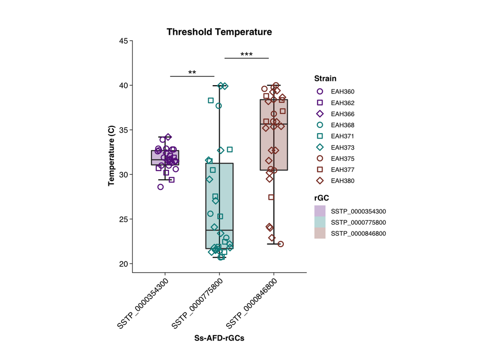

```r
stat.test.ectopic.thresh <- dplyr::tibble(
  comparisons = post.hoc$comparisons,
  p.adj = post.hoc$P.adjusted,
  p.adj.signif = stars.pval(post.hoc$P.adjusted)
) %>%
  mutate(p.adj.signif = case_when(p.adj.signif == " " ~ "ns",
                                  TRUE ~ as.character(p.adj.signif))) %>%
  tidyr::separate(comparisons,
                  into = c("group1", "group2"),
                  sep = " - ")

p_ectopic_thresh<- plot_ectopic_noctrl(dat.subset,
                                       dat.subset$Thresh_temp,
                                       meta_ectopic,
                                       ylim,
                                       xlabel,
                                       ylabel,
                                       stat.test.ectopic.thresh,
                                       41,
                                       title)


print(p_ectopic_thresh)
```

## 4.4 Temperature driving maximum response

Stats are Kruskal-Wallis Test with Dunn’s Post tests for difference in response amplitude.

```r
# Kruskal-Wallis testing of response amplitude differenec
one.way <- kruskal.test(Tmax ~ rGC,
                        data = dat.subset)

# Posthoc Dunn tests with Bonferroni adjustment
post.hoc <- dunn.test::dunn.test(dat.subset$Tmax,
                                 dat.subset$rGC,
                                 method = "bonferroni",
                                 table = FALSE,
                                 list = TRUE)
```

```
##   Kruskal-Wallis rank sum test
##
## data: x and group
## Kruskal-Wallis chi-squared = 20.8532, df = 2, p-value = 0
##
##
##                            Comparison of x by group
##                                  (Bonferroni)
##
## List of pairwise comparisons: Z statistic (adjusted p-value)
## -------------------------------------------------------
## SSTP_0000354300 - SSTP_0000775800 : -1.123800 (0.3916)
## SSTP_0000354300 - SSTP_0000846800 : -4.339425 (0.0000)*
## SSTP_0000775800 - SSTP_0000846800 : -3.337010 (0.0013)*
##
## alpha = 0.05
## Reject Ho if p <= alpha/2
```

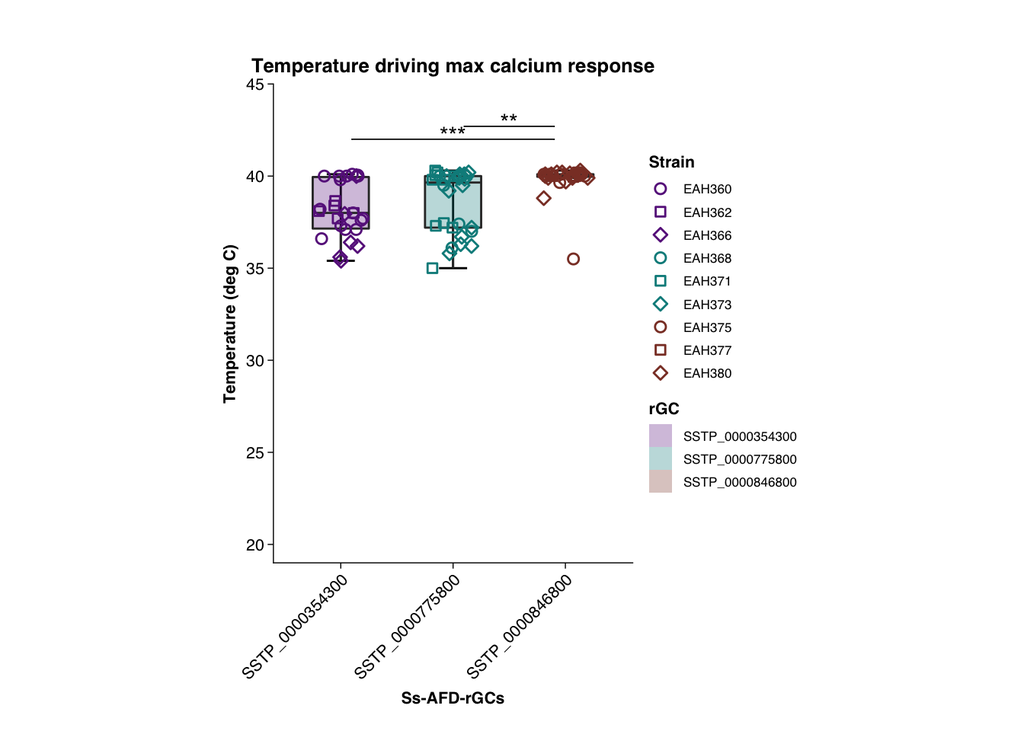

```r
xlabel <- "Ss-AFD-rGCs"
ylabel <- "Temperature (deg C)"
title <- "Temperature driving max calcium response"
ylim <- c(19,45)

stat.test.ectopic.Tmax <- dplyr::tibble(
  comparisons = post.hoc$comparisons,
  p.adj = post.hoc$P.adjusted,
  p.adj.signif = stars.pval(post.hoc$P.adjusted)
) %>%
  mutate(p.adj.signif = case_when(p.adj.signif == " " ~ "ns",
                                  TRUE ~ as.character(p.adj.signif))) %>%
  tidyr::separate(comparisons,
                  into = c("group1", "group2"),
                  sep = " - ")

p_Tmax<- plot_ectopic_noctrl(dat.subset,
                             dat.subset$Tmax,
                             meta_ectopic,
                             ylim,
                             xlabel,
                             ylabel,
                             stat.test.ectopic.Tmax,
                             42,
                             title)

# ggsave("Ss-AFD-rGCsTmax.eps",
#        plot = p_Tmax,
#        device = "eps",
#        width = 3.5,
#        path = dirname(dat_ectopic_file))

print(p_Tmax)
```

## 4.5 Group and Save Ectopic Plots

```r
ggarrange(
  p_ectopic_thresh,
  p_Tmax,
  ncol = 2,
  nrow = 1
) %>%
ggsave(filename ="rGC_Plots.pdf",
       device = cairo_pdf,
       width = 7,
       # height = 3.5,
       path = dirname(dat_AFD_file))
plot_ectopic <- function(dat, y, meta, ylim, xlabel, ylabel, title = NULL){
  ggplot(data = dat, mapping = aes(x = rGC, y = y)) +
    # stat_boxplot(geom = "errorbar", width = 0.4) +
    # geom_boxplot(width = 0.6,
    #              outlier.shape = NA,
    #              fatten = 1.5,
    #              key_glyph = "rect",
    #              alpha = 0.7,
    #              aes(fill = rGC)) +
    geom_violin(#alpha = 0.5,
      aes(fill = rGC)) +
    geom_jitter(size = 2,
                stroke = .75,
                width = .2,
                aes(color = Strain, shape = Strain)) +
    stat_summary(fun.data = "median_hilow",
                 size = .2,
                 geom = "pointrange",
                 fun.args = list(conf.int = .5)) +
    scale_y_continuous(limits = ylim,
                       expand = expansion(add = 0)) +
    xlab(xlabel) +
    ylab(ylabel) +
    ggtitle(title) +
    #scale_color_manual(values = c("black","darkorchid4", "cyan4", "coral4"))+
    scale_fill_manual(values = c("black","darkorchid4", "cyan4", "coral4"))+
    scale_color_manual(values = c(rep(c("darkorchid4", "cyan4", "coral4"),each = 3),"grey")) +
    #scale_shape_manual(values = rep(c(21:23), 3))  +
    scale_shape_manual(values = c(21:23, 21:23, 21:23, 24))  +
    theme_Publication() +
    theme(aspect.ratio = 4/3)
}
```